# 2 Rikollisuuden rakenne ja kehitys

*Ilari Kolttola*

## 2.1 Tiivistelmä

Rikollisuuden rakennetta ja kehitystä tarkastellaan seuraavassa viranomaisten tilastoiman rikollisuuden pohjalta. Pääosa rikoksista on poliisin tilastoimaa. Myös Tulli ja Rajavartiolaitos kirjaavat rikoksia.

**Rikollisuuden kehityksen tarkasteleminen viranomaisten tilastojen pohjalta**

- Rikollisuustilanne katsauksessa rikosten määrän kehitystä kuvataan mm. tietoon tulleiden rikosten avulla. Tämä Tilastokeskuksen tuottama tilasto kertoo Poliisin, Tullin ja Rajavartioston tietojärjestelmiin rikoksena tallennetuista rikoksista. Rikokset tilastoidaan tässä tapauksessa rikosperustaisesti. Tämä tilasto kertoo yksittäisten rikosten, ei tekijöiden tai uhrien määrää. Onkin syytä huomioida, että yksi uhriin kohdistunut teko voi pitää sisällään useampia rikoksia. Esimerkkinä tilaston kuvaustavasta voi nostaa vuoden 2020 Vastaamon tietomurtotapauksen (useita tuhansia uhreja), joka näkyy mm. kahtena eri tietomurtona, tuhansina kiristysrikoksina, tuhansina kiristyksen yrityksinä ja tuhansina yksityiselämää loukkaavan tiedon levittämisinä.
- Tässä katsauksessa rikosten piirteitä kuvataan myös tekijöiden ja uhrien näkökulmasta. Tekijäpohjaisista tilastoista on syytä huomioida, että tiedot ovat usein ns. bruttolukuja. Yksi henkilö voi näkyä tilastossa useampaan kertaan, mikäli hän on epäiltynä useasta rikoksesta. Lisäksi yhtä rikosta kohden voi olla useampi epäilty. Samalla tavalla myös yksittäinen uhri voi olla uhrina useammassa rikoksessa. Epäilty tai uhri on siis tilastossa rikoskohtaisesti, ei henkilöperustaisesti. Nämä tekijät on syytä ottaa huomioon erityisesti eri taustatekijöihin/-ryhmiin liittyvissä analyyseissä, kuten epäiltyjen sosioekonomiseen asemaan, ikään tai taustamaahan liittyvissä johtopäätöksissä. Huomiointi on erityisen tärkeää, mikäli tarkasteltava ryhmä on henkilömäärältään pieni ja mikäli tarkasteltavia rikoksia tapahtuu kokonaisuudessa vähän. Yksi useamman rikoksen tehnyt henkilö voi siis periaatteessa nostaa koko ryhmän keskiarvoa merkittävästi (ks. alla oleva esimerkki).
- Rikokset jaotellaan tilastoissa pääsääntöisesti omina tapahtuminaan. Epäilty voi esimerkiksi pahoinpidellä samaa uhria eri ajankohtina kuusi kertaa. Tämä näkyy tietoon tulleissa rikoksissa kuutena pahoinpitelynä, tekijäpohjaisessa tilastossa taas kuutena epäiltynä. Pelkästään näistä tiedoista ei siis voi suoraan päätellä uhrien tai tekijöiden nettomäärää. Osa rikoksista, ns. tapahtumakertarikokset, poikkeavat kuitenkin tästä tilastoinnista. Esimerkiksi kavallus kirjataan yhtenä rikoksena, vaikka itse rikokseen liittyviä tapahtumakertoja olisi useampia. (ks. lisätietona esim. Haapakangas 2021.)
- Ajallisesti tilastotiedot kuvaavat pääsääntöisesti rikosten tietoontuloaikaa eli aikaa, jolloin rikos tulee poliisiin tietoon. Esimerkkinä voidaan nostaa Vastaamon tietomurrot, jotka on arvioitu tapahtuneen vuosina 2018–2019. Tilastoissa nämä rikokset näkyvät kuitenkin tietoontulovuonna 2020. Selvitetyt rikokset kuvataan taas rikosten selvitysvuoden mukaan, ei tietoontulovuoden mukaan.
- Tilastoidun rikollisuuden ulkopuolelle jäävät rikokset, joita ei ole ilmoitettu poliisille tai jotka muusta syystä eivät ole tulleet viranomaisten tietoon. Suuri osa kaikista lainvastaisista teoista ei tule viranomaisten tietoon. Rikosten ilmituloaste vaihtelee paljon rikoslajeittain. Eräiden rikosten ilmitulo riippuu miltei kokonaan poliisin ja muiden kontrolliviranomaisten toiminnasta. Piiloon jäänyttä rikollisuutta pyritään selvittämään mm. Uhritutkimuksin (ks. esim. kpl 3).
- Tämän katsauksen kappaleiden alussa kerrotaan kappaleen kannalta relevanteista tietolähteistä ja niihin olennaisesti liittyvistä ongelmista. Lisätietoa rikosten tilastoinnista löytyy tämän katsauksen B3 kappaleesta *Miten rikoksia tilastoidaan Suomessa.*

*Lähde*: Haapakangas 2021; Tilastokeskus 2020

**Taulukko 1** Poliisin tietoon tulleet rikokset, liikenteeseen liittyvät rikkomukset ja muut rikkomukset vuonna 2024

| **Rikoslaji** | **Lukumäärä** |  | **Osuus (%)** |  |
| --- | --- | --- | --- | --- |
| **Omaisuusrikokset** | **254 315** |  | **48 %** |  |
| …varkausrikokset |  | 131 023 | … | 25 % |
| **Henkeen ja terveyteen kohdistuneet rikokset** | **44 246** |  | **8 %** |  |
| …pahoinpitelyrikokset |  | 41 498 | … | 8 % |
| …murhat, tapot ja surmat (pl. yritykset) |  | 89 | … | 0 % |
| **Seksuaalirikokset** | **9 608** |  | **2 %** |  |
| …raiskaukset, törkeät raiskaukset |  | 253 | … | 0 % |
| **Huumausainerikokset** | **25 618** |  | **5 %** |  |
| …törkeät huumausainerikokset |  | 1 986 | … | 0 % |
| **Liikennerikokset** | **118 425** |  | **22 %** |  |
| …rattijuopumukset |  | 14 472 | … | 3 % |
| Muut rikokset ja rikkomukset (pl. liikennerikkomukset) | **82 488** |  | **15 %** | … |
| …rikokset oikeudenkäyttöä, viranomaisia, ym. vastaan |  | 14 283 | … | 3 % |
| …järjestysrikkomukset |  | 1 552 | … | … |
| …yksityisyyden, rauhan ja kunnian loukkaaminen |  | 17 419 | … | 3 % |
| …alkoholirikokset ja -rikkomukset |  | 978 | … | … |
| **Yhteensä**** | **534 699** |  | **100 %** |  |
| …joista rikoslakirikoksia |  | 522 044 | … | 98 % |
| **Liikennerikkomukset ym.*** | **5 020** | … | 1 % | … |
| **Rikokset ja rikkomukset yhteensä** | **539 719** | … | … | … |

* Liikennerikkomus (TLL 103 §), tieliikenteen sosiaalilainsäädännön rikkominen (TLL 105a §/laki liikenteen palveluista 267 §), ajoneuvorikkomus (ajoneuvolaki 96 §), ajokorttirikkomus (ajokorttilaki 93 §).

** Pyöristyksestä johtuen prosenttiosuuksien summat voivat poiketa sadasta.

*Lähde*: Tilastokeskus, rikos- ja pakkokeinotilasto (Tilastokeskus 2025a)

Eri rikoslajien kehitys riippuu paitsi rikollisuuden todellisesta lisääntymisestä tai vähenemisestä, myös siitä, miten aktiivisesti rikosten uhriksi joutuneet ilmoittavat niistä poliisille. Poliisilta piiloon jäävien rikosten osuus on usein suurempi niin sanotuissa massarikoksissa, kun taas vakavammat rikokset tulevat herkemmin poliisin tietoon. Ilmitulleiden rikosten määrään vaikuttaa myös viranomaisten valvonnan tehokkuus ja se, miten valvontaa suunnataan. Tilastoituun rikollisuuteen vaikuttavat lisäksi lainsäädännön muutokset ja rikosten kirjaamisessa tapahtuneet muutokset.

Kuvio 1 näyttää kaikkien rikoslakirikosten sekä varkausrikosten ja pahoinpitelyrikosten kehityksen viimeisen 30 vuoden aikana. Vertailun helpottamiseksi kaikkien rikosten ja varkausrikosten määrä esitetään väestön 10 000 asukasta kohden, pahoinpitelyrikokset väestön 100 000 asukasta kohden. Taulukossa 2 esitetään myös eräiden muiden rikosten väkilukuun suhteutettu määrä viimeisen kymmenen vuoden aikana.

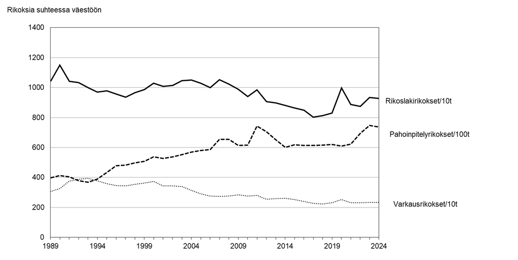

Pahoinpitelyrikokset 100 000 asukasta kohti ovat lisääntyneet 1990-luvulta, kun taas varkausrikokset ovat vähentyneet. Kokonaisuudessaan rikoslakirikokset ovat vähentyneet 30 vuodessa, vaikkakin viime vuosina rikoslakirikokset ovat kääntyneet nousuun.

**Kuvio 1** Poliisin tietoon tulleet rikokset vuosina 1989–2024. Kaikki rikoslakirikokset ja varkausrikokset 10 000 asukasta kohti, pahoinpitelyrikokset 100 000 asukasta kohti. *Lähteet:* Tilastokeskus, rikos- ja pakkokeinotilasto (Tilastokeskus 2025a); Tilastokeskus, väestörakenne (Tilastokeskus 2025b).

Kaikkien rikosten kokonaismäärä on ollut pääosin laskusuuntainen vuoden 1990 jälkeen. Vuonna 1990 rikosten määrä oli 1 150 rikosta väestön 10 000 asukasta kohti, kun taso vuonna 2024 oli 926. Viimevuosina rikosten väheneminen on kuitenkin katkennut ja rikoslakirikosten määrä on kääntynyt lievään nousuun.

Varkausrikoksien määrässä ei ole viimevuosina tapahtunut juurikaan muutosta, kun taas kavallus- ja petosrikokset sen sijaan ovat lisääntyneet merkittävästi. Vuonna 2024 ryöstörikokset laskivat hieman vuodesta 2023, ollen kuitenkin tarkastelujakson toiseksi korkein, 46 rikosta 100 000 asukasta kohden (taulukko 2).

**Taulukko 2** Poliisin tietoon tulleet rikokset väestön 100 000 asukasta kohti 2015–2024

|  | **2015** | **2016** | **2017** | **2018** | **2019** | **2020** | **2021** | **2022** | **2023** | **2024** |
| --- | --- | --- | --- | --- | --- | --- | --- | --- | --- | --- |
| Tappo, murha, surma (pl. yritykset) | 1,7 | 1,4 | 1,3 | 1,6 | 1,3 | 1,6 | 1,5 | 1,4 | 1,0 | 1,6 |
| Ryöstörikokset | 28 | 30 | 30 | 31 | 33 | 36 | 34 | 42 | 49 | 46 |
| Pahoinpitelyrikokset | 617 | 614 | 614 | 615 | 620 | 609 | 622 | 694 | 746 | 736 |
| Varkausrikokset | 2520 | 2388 | 2279 | 2230 | 2305 | 2524 | 2313 | 2319 | 2333 | 2325 |
| Vahingonteko | 686 | 639 | 610 | 555 | 557 | 612 | 581 | 566 | 555 | 562 |
| Kavallus- ja petosrikokset<sup>1</sup> | 727 | 783 | 622 | 639 | 724 | 845 | 872 | 987 | 1127 | 1245 |
| Rattijuopumus | 321 | 315 | 321 | 345 | 335 | 366 | 314 | 290 | 284 | 257 |

<sup>1</sup>(ei sis. veropetoksia)

*Lähteet*: Tilastokeskus, rikos- ja pakkokeinotilasto (Tilastokeskus 2025a); Tilastokeskus, väestörakenne (Tilastokeskus 2025b).

## 2.2 Lähteet

Tilastokeskus. 2025a. Rikos- ja pakkokeinotilasto. Helsinki: Tilastokeskus.

https://stat.fi/til/rpk/

Tilastokeskus. 2025b. Väestörakenne. Helsinki: Tilastokeskus.

https://www.stat.fi/til/vaerak

Haapakangas, Kimmo. 2021. Yksi rikos, monta osatekoa – miten rikoksia tilastoidaan? Tilastokeskus. https://www.stat.fi/tietotrendit/blogit/2021/yksi-rikos-monta-osatekoa-miten-rikoksia-tilastoidaan/.